# cardinal fitness — results summaries

## Fecundity

Fecundity (egg count per well) was modelled using a zero-inflated negative binomial mixed model with cross direction and genetic line as fixed effects, and replicate and plate well as nested random effects (n = 341 observations across 340 wells, 10 replicates).

```r
tab_model(egg_model)
```

|  | eggs |  |  |  |
| --- | --- | --- | --- | --- |
| Predictors | Incidence Rate Ratios | CI | p |  |
| Count Model |  |  |  |  |
| (Intercept) | 96.40 | 84.34 – 110.19 | **<0.001** |  |
| cross [HOMxSDA] | 0.69 | 0.55 – 0.86 | **0.001** |  |
| cross [SDAxHET] | 0.98 | 0.82 – 1.17 | 0.818 |  |
| cross [SDAxHOM] | 0.89 | 0.73 – 1.09 | 0.273 |  |
| line [2360B5] | 0.93 | 0.71 – 1.22 | 0.613 |  |
| line [QA383P] | 1.06 | 0.92 – 1.22 | 0.434 |  |
| (Intercept) | 43.19 | 22.68 – 93.95 |  |  |
| Zero-Inflated Model |  |  |  |  |
| (Intercept) | 0.25 | 0.14 – 0.45 | **<0.001** |  |
| cross [HOMxSDA] | 4.80 | 2.36 – 9.78 | **<0.001** |  |
| cross [SDAxHET] | 0.64 | 0.29 – 1.41 | 0.265 |  |
| cross [SDAxHOM] | 1.73 | 0.82 – 3.68 | 0.151 |  |
| line [2360B5] | 6.14 | 2.48 – 15.21 | **<0.001** |  |
| line [QA383P] | 0.97 | 0.56 – 1.66 | 0.901 |  |
| Random Effects |  |  |  |  |
| σ<sup>2</sup> |  |  |  |  |
| τ<sub>00</sub> <sub>plate_well:rep</sub> | 0.00 |  |  |  |
| τ<sub>00</sub> <sub>rep</sub> | 0.00 |  |  |  |
| N <sub>plate_well</sub> | 340 |  |  |  |
| N <sub>rep</sub> | 10 |  |  |  |
| Observations | 341 |  |  |  |

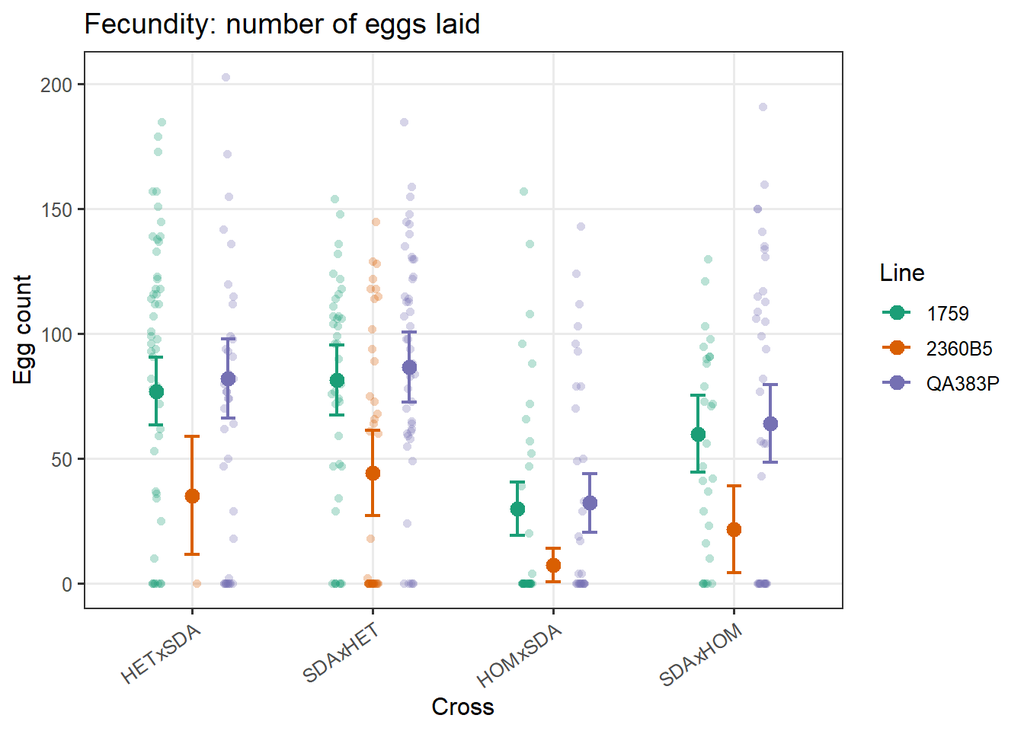

```r
p_fecundity
```

## Fertility

Hatching rate (larvae per egg) was modelled using a binomial GLMM with a combined line × cross factor as the fixed effect, and nested random effects of plate well within replicate within line-cross group (n = 257 observations; marginal R² = 0.45).

All comparisons are relative to the reference group (1759 HET×SDA). Most cross types within the 1759 line did not differ significantly in hatching rate. A striking exception was the 1759 SDA×HOM cross, which showed near-zero hatching relative to the reference (OR = 0.01, 95% CI: 0.01–0.04, p < 0.001), indicating that 1759 homozygous males are essentially sterile. The single included 2360B5 cross (SDA×HET) did not differ significantly from the reference (OR = 0.80, p = 0.638). In contrast, all tested QA383P crosses showed equal or significantly higher hatching rates than the 1759 reference, with the QA383P SDA×HET cross showing the largest increase (OR = 5.55, 95% CI: 2.64–11.69, p < 0.001). These results suggest that homozygous 1759 males have a severe fertility defect, while the KO line (QA383P) does not share this phenotype.

```r
tab_model(larvae_model2)
```

|  | cbind(larvae,(eggs-larvae)) |  |  |
| --- | --- | --- | --- |
| Predictors | Odds Ratios | CI | p |
| (Intercept) | 3.41 | 2.04 – 5.71 | **<0.001** |
| line cross [1759_HOMxSDA] | 0.90 | 0.30 – 2.64 | 0.843 |
| line cross [1759_SDAxHET] | 1.04 | 0.48 – 2.27 | 0.916 |
| line cross [1759_SDAxHOM] | 0.01 | 0.01 – 0.04 | **<0.001** |
| line cross [2360B5_SDAxHET] | 0.80 | 0.32 – 1.99 | 0.638 |
| line cross [QA383P_HETxSDA] | 2.50 | 1.11 – 5.61 | **0.027** |
| line cross [QA383P_HOMxSDA] | 2.37 | 0.89 – 6.31 | 0.083 |
| line cross [QA383P_SDAxHET] | 5.55 | 2.64 – 11.69 | **<0.001** |
| line cross [QA383P_SDAxHOM] | 3.65 | 1.52 – 8.78 | **0.004** |
| Random Effects |  |  |  |
| σ<sup>2</sup> | 2.73 |  |  |
| τ<sub>00</sub> <sub>plate_well:rep:line_cross</sub> | 2.69 |  |  |
| τ<sub>00</sub> <sub>rep:line_cross</sub> | 0.00 |  |  |
| τ<sub>00</sub> <sub>line_cross</sub> | 0.00 |  |  |
| N <sub>plate_well</sub> | 257 |  |  |
| N <sub>rep</sub> | 10 |  |  |
| N <sub>line_cross</sub> | 9 |  |  |
| Observations | 257 |  |  |
| Marginal R<sup>2</sup> / Conditional R<sup>2</sup> | 0.454 / NA |  |  |

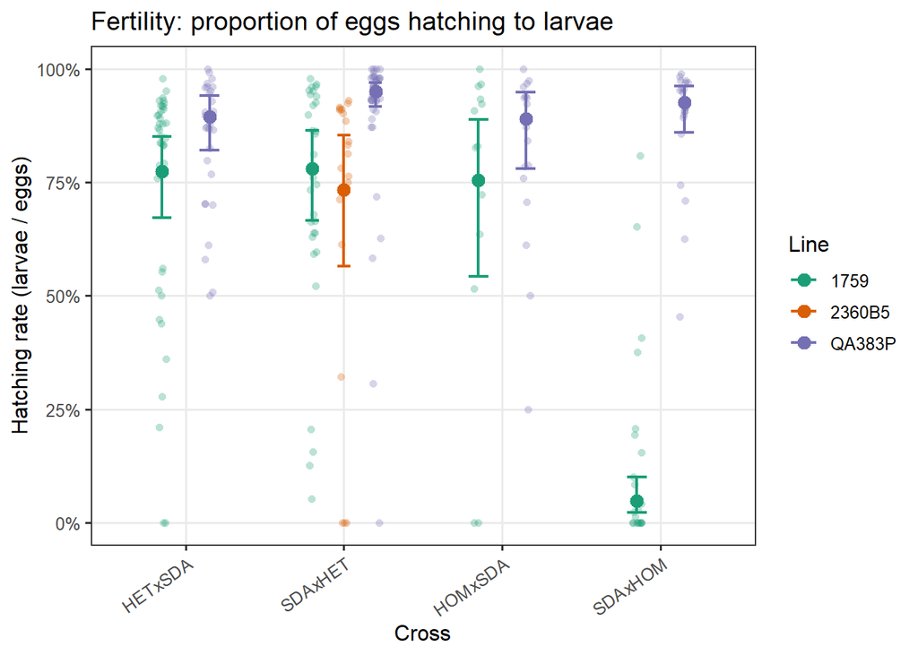

```r
p_fertility
```

## Survival after Blood Feeding

Post-blood-feeding survival was modelled using a Weibull parametric survival model with a single combined line × genotype factor (n = 384). Model estimates are scale factors relative to the reference group (1759 Het); values below 1 indicate shorter survival.

All KI heterozygote lines showed substantially reduced survival relative to 1759 Het. The 2301 Het and 2360B5 Het groups had the most severe phenotypes, with scale estimates of 0.05 (95% CI: 0.03–0.07, p < 0.001) and 0.06 (95% CI: 0.04–0.10, p < 0.001) respectively. The 2072 Het group also showed markedly reduced survival (estimate = 0.13, 95% CI: 0.08–0.21, p < 0.001). Within line 1759, homozygotes survived considerably less well than heterozygotes (estimate = 0.27, 95% CI: 0.17–0.42, p < 0.001), while WT siblings were not significantly different (estimate = 1.37, p = 0.185). WT survival did not differ significantly from 1759 Het in the 2072 line (estimate = 0.80, p = 0.353), and the 2301 WT estimate was highly unstable, consistent with near-complete survival in that group. D251 homozygotes showed a non-significant trend toward shorter survival (estimate = 0.67, p = 0.095), whereas D251 WT mosquitoes unexpectedly showed shorter survival than 1759 Het (estimate = 0.47, 95% CI: 0.30–0.75, p = 0.001). 2360B5 WT survived longer than 1759 Het (estimate = 1.84, 95% CI: 1.15–2.92, p = 0.010).

```r
tab_model(model)
```

```
`r2()` does not support models of class `flexsurvreg`.
```

|  | Surv(Hours,event) |  |  |
| --- | --- | --- | --- |
| Predictors | Estimates | CI | p |
| shape | 1.38 | 0.73 – 2.60 | 0.327 |
| scale | 1674.60 | 0.00 – Inf | 0.985 |
| line treatment [1759_Hom] | 0.27 | 0.17 – 0.42 | **<0.001** |
| line treatment [1759_WT] | 1.37 | 0.86 – 2.18 | 0.185 |
| line treatment [2072_Het] | 0.13 | 0.08 – 0.21 | **<0.001** |
| line treatment [2072_WT] | 0.80 | 0.50 – 1.28 | 0.353 |
| line treatment [2301_Het] | 0.05 | 0.03 – 0.07 | **<0.001** |
| line treatment [2301_WT] | 346544.01 | 0.00 – Inf | 0.996 |
| line treatment [2360B5_Het] | 0.06 | 0.04 – 0.10 | **<0.001** |
| line treatment [2360B5_WT] | 1.84 | 1.15 – 2.92 | **0.010** |
| line treatment [D251_Hom] | 0.67 | 0.42 – 1.07 | 0.095 |
| line treatment [D251_WT] | 0.47 | 0.30 – 0.75 | **0.001** |
| Observations | 384 |  |  |

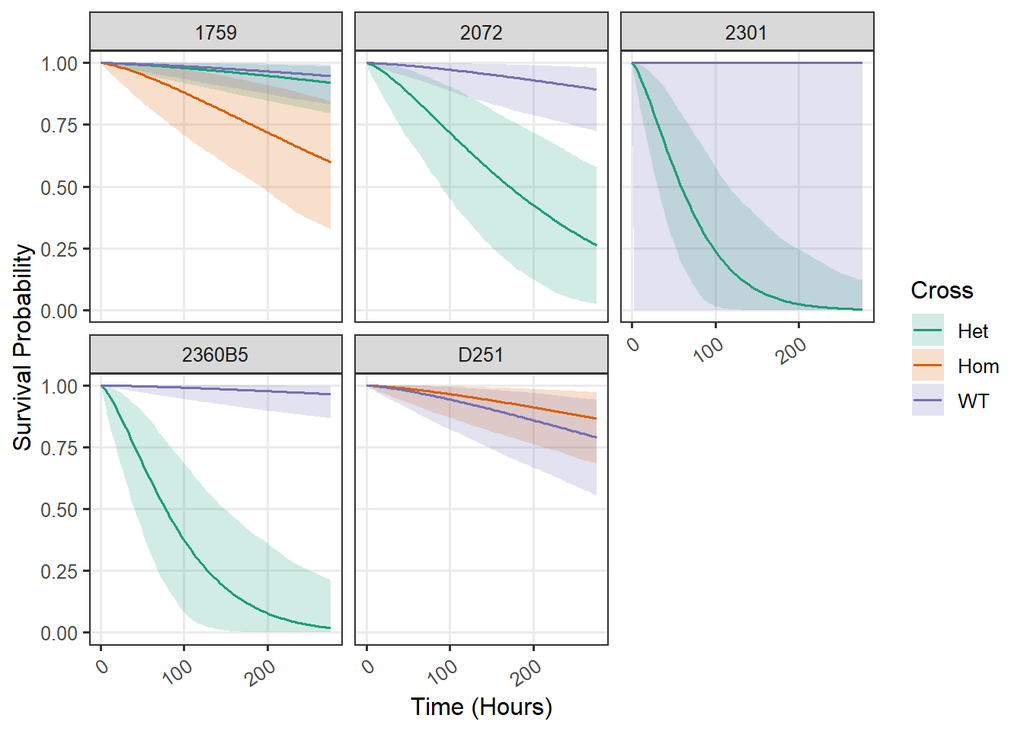

```r
survival_after_blood
```

## TransHet survival

D251 Het mosquitoes did not differ significantly from 2360B5 Het (estimate = 0.97, 95% CI: 0.40–2.34, p = 0.944). D251 WT mosquitoes showed dramatically extended survival relative to 2360B5 Het (estimate = 12218566.26, 95% CI: 0.00–Inf, p = 0.997), though the estimate is highly unstable, suggesting complete or near-complete separation in the data. Within the 2360B5 line, WT mosquitoes survived substantially longer than Het mosquitoes (estimate = 26.66, 95% CI: 11.04–64.38, p < 0.001). These results indicate that WT mosquitoes in both lines survive much longer than their KI heterozygote counterparts, but do not provide clear evidence that the D251 KO allele rescues the KI survival phenotype.

```r
tab_model(model_transhet)
```

```
`r2()` does not support models of class `flexsurvreg`.
```

|  | Surv(Hours,event) |  |  |
| --- | --- | --- | --- |
| Predictors | Estimates | CI | p |
| shape | 1.34 | 0.41 – 4.33 | 0.630 |
| scale | 70.89 | 0.00 – 98038538547623231456082028620.00 | 0.894 |
| line treatment [2360WT] | 26.66 | 11.04 – 64.38 | **<0.001** |
| line treatmentD251 × 2360Het | 0.97 | 0.40 – 2.34 | 0.944 |
| line treatmentD251 × 2360WT | 12218566.26 | 0.00 – Inf | 0.997 |
| Observations | 186 |  |  |

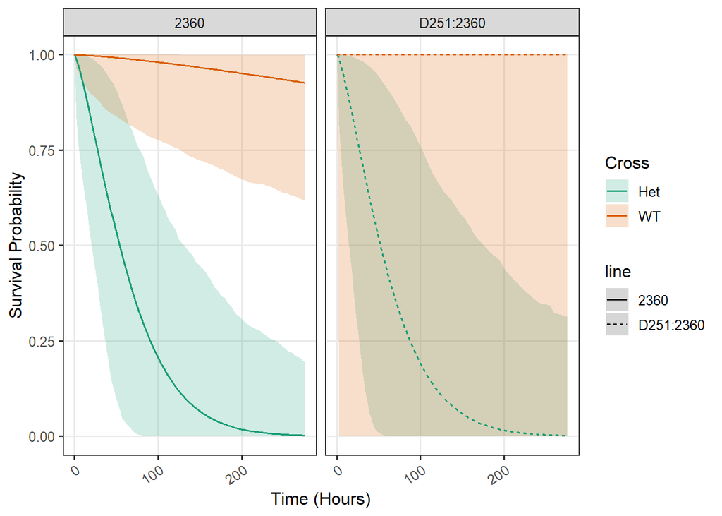

```r
transhet_survival
```

## Smurf assay

Midgut integrity was assessed using the smurf assay. The proportion of smurf-positive mosquitoes (indicating gut barrier disruption) was modelled using a binomial GLM with genotype, delivery treatment (sucrose, TRP, NaOH), and their interaction as predictors (n = 27 cage-level observations; XA delivery excluded). The reference group was WT mosquitoes on sucrose.

KI mosquitoes on sucrose had a dramatically elevated smurf rate compared to WT controls (OR = 65.61, 95% CI: 25.70–205.20, p < 0.001), confirming that the cardinal KI allele causes significant gut barrier disruption after blood feeding. The KO genotype on sucrose showed a smurf rate consistent with zero events (estimate approaching 0, p = 0.996), reflecting complete separation and no observed smurf-positive cases. NaOH delivery did not significantly alter smurf rate in either WT (OR = 0.62, p = 0.487) or KI mosquitoes relative to their respective sucrose groups (KI × NaOH interaction: OR = 0.55, p = 0.431). TRP-related terms showed extreme estimates driven by complete separation, preventing reliable interpretation. Taken together, the data indicate that the KI phenotype includes midgut barrier disruption, and that pH adjustment via NaOH does not significantly rescue this defect.

```r
tab_model(smurf_model)
```

|  | cbind(positive,negative) |  |  |
| --- | --- | --- | --- |
| Predictors | Odds Ratios | CI | p |
| (Intercept) | 0.06 | 0.02 – 0.13 | **<0.001** |
| genotype [KI] | 65.61 | 25.70 – 205.20 | **<0.001** |
| genotype [KO] | 0.00 | 0.00 – 1129001510255318796240680446842664668688222248860226486888808800284422.00 | 0.996 |
| delivery [NAOH] | 0.62 | 0.15 – 2.41 | 0.487 |
| delivery [TRP] | 0.00 | 0.00 – 3979325027006505020044646888282686604806064608242666040460484424060.00 | 0.996 |
| genotype [KI] × delivery [NAOH] | 0.55 | 0.12 – 2.58 | 0.431 |
| genotype [KO] × delivery [NAOH] | 67839510.64 | 0.00 – Inf | 0.996 |
| genotype [KI] × delivery [TRP] | 95204834.90 | 0.00 – Inf | 0.996 |
| genotype [KO] × delivery [TRP] | 23240696817673812.00 | 0.00 – Inf | 0.995 |
| Observations | 27 |  |  |

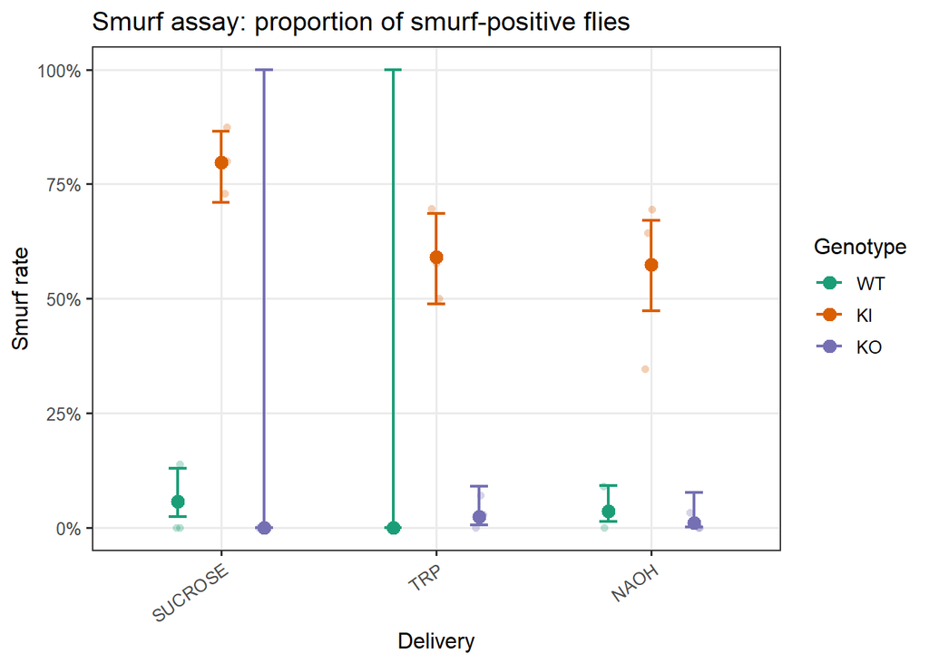

```r
p_smurf
```

## XA Supplementation

The effect of xanthurenic acid (XA) supplementation on post-blood-feeding survival was examined using a Weibull parametric survival model (n = 387). Predictors were supplementation route (blood vs sugar), XA dose (0, 6, or 24 mM), genotype (Het vs WT), and whether XA was present (c_minus: “+” = XA present, “−” = NaOH control), with an interaction between route and XA presence. The reference group was Het mosquitoes receiving blood supplementation at 0 mM in the NaOH control condition.

Sugar supplementation was associated with substantially longer survival than blood supplementation (estimate = 1.96, 95% CI: 1.39–2.78, p < 0.001). WT mosquitoes survived considerably longer than Het mosquitoes across conditions (estimate = 4.69, 95% CI: 2.69–8.19, p < 0.001). A dose of 6 mM XA significantly extended survival relative to the 0 mM condition (estimate = 1.34, 95% CI: 1.03–1.76, p = 0.031), while 24 mM XA did not differ significantly from 0 mM (estimate = 0.90, p = 0.409). The presence of XA (c+ condition) was associated with longer survival overall compared to NaOH control (estimate = 1.59, 95% CI: 1.13–2.21, p = 0.007). The interaction between sugar supplementation and XA presence showed a trend toward a reduced benefit of XA in the sugar route (estimate = 0.69, 95% CI: 0.46–1.02, p = 0.064), though this did not reach statistical significance. These results indicate that 6 mM XA supplementation via the blood route partially rescues the post-blood-feeding survival defect in KI heterozygotes.

```r
tab_model(model4)
```

```
`r2()` does not support models of class `flexsurvreg`.
```

|  | Surv(Hours,event) |  |  |
| --- | --- | --- | --- |
| Predictors | Estimates | CI | p |
| shape | 2.35 | 1.54 – 3.58 | **<0.001** |
| scale | 65.15 | 0.00 – 1715741658762.75 | 0.733 |
| experiment [sugar supplementation] | 1.96 | 1.39 – 2.78 | **<0.001** |
| dosage mM [6] | 1.34 | 1.03 – 1.76 | **0.031** |
| dosage mM [24] | 0.90 | 0.71 – 1.15 | 0.409 |
| genotype [WT] | 4.69 | 2.69 – 8.19 | **<0.001** |
| c minus [+] | 1.59 | 1.13 – 2.21 | **0.007** |
| experiment [sugar supplementation] × c minus [+] | 0.69 | 0.46 – 1.02 | 0.064 |
| Observations | 387 |  |  |

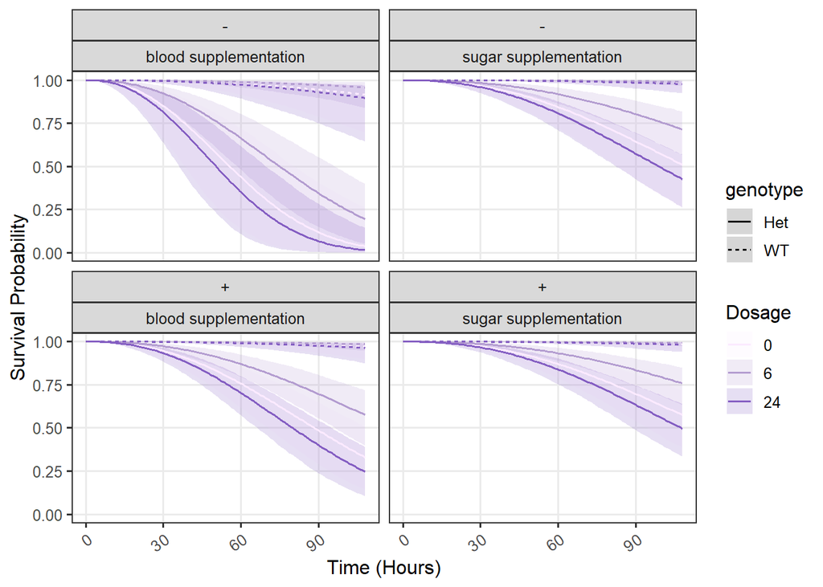

```r
XA_suppl
```

## Homozygous Survival

Homozygous viability was assessed by scoring adult eclosion from balanced crosses. The proportion of adults eclosing out of an expected 200 was modelled with a binomial GLM including line (1759 vs QA383P), genotype (HET, HOM, WT), sex, and all two- and three-way interactions (n = 24 observations). The reference cell was 1759, HET, female.

Homozygous 1759 females showed near-complete failure to eclose (Genotype HOM: OR = 0.01, 95% CI: 0.00–0.02, p < 0.001), demonstrating strong homozygous lethality in this KI line. WT 1759 females also showed slightly reduced eclosion relative to HET females (OR = 0.75, 95% CI: 0.56–0.99, p = 0.040). In 1759, homozygous males survived substantially better than homozygous females (HOM × male: OR = 23.76, 95% CI: 8.30–100.36, p < 0.001), indicating a sex-specific partial rescue of homozygous lethality. WT males also had modestly higher eclosion than WT females (WT × male: OR = 1.70, 95% CI: 1.15–2.52, p = 0.008). The QA383P line showed strikingly different homozygous viability: QA383P HOM females eclosed at near-normal rates relative to 1759 HET females (QA383P × HOM interaction: OR = 163.35, 95% CI: 58.53–681.41, p < 0.001), indicating that the KO allele does not share the strong homozygous lethality of the KI. However, the three-way interaction (QA383P × HOM × male: OR = 0.03, 95% CI: 0.01–0.09, p < 0.001) indicates that the sex-specific rescue seen in 1759 is reversed in QA383P, with QA383P HOM males ecloding less well than QA383P HOM females.

```r
tab_model(model)
```

|  | cbind(Adults,200-Adults) |  |  |
| --- | --- | --- | --- |
| Predictors | Odds Ratios | CI | p |
| (Intercept) | 1.01 | 0.83 – 1.23 | 0.920 |
| line [QA383P] | 0.82 | 0.62 – 1.08 | 0.157 |
| Genotype [HOM] | 0.01 | 0.00 – 0.02 | **<0.001** |
| Genotype [WT] | 0.75 | 0.56 – 0.99 | **0.040** |
| Sex [male] | 0.87 | 0.66 – 1.15 | 0.322 |
| line [QA383P] × Genotype [HOM] | 163.35 | 58.53 – 681.41 | **<0.001** |
| line [QA383P] × Genotype [WT] | 1.27 | 0.86 – 1.89 | 0.230 |
| line [QA383P] × Sex [male] | 1.32 | 0.89 – 1.96 | 0.161 |
| Genotype [HOM] × Sex [male] | 23.76 | 8.30 – 100.36 | **<0.001** |
| Genotype [WT] × Sex [male] | 1.70 | 1.15 – 2.52 | **0.008** |
| (line [QA383P] × Genotype [HOM]) × Sex [male] | 0.03 | 0.01 – 0.09 | **<0.001** |
| (line [QA383P] × Genotype [WT]) × Sex [male] | 0.70 | 0.40 – 1.23 | 0.215 |
| Observations | 24 |  |  |